# Module Seven Activity

For the module seven activity, you will identify relevant data and write Python code to generate visualizations and interpret insights from the provided data set. Professionals in data-driven fields must not only interpret data but also gather, analyze, and present it in meaningful and actionable ways. This activity allows you to practice these essential skills by working through the complete exploratory data analysis (EDA) process.

*Note:* there are two parts to this assignment. Part One is the coding activity. Part Two is the written report.

Once your code is complete, you will download this notebook as an HTML file by clicking **File**, then **Download As**, then **HTML (.html)** from the Jupyter menu bar. Validate that your code, output, and all visualizations (rendered as images using the display() function) are visible in the html file before submission.

*Missing Blocks:* Ensure that you have clicked **Run** for all blocks before downloading as an HTML file or the block may be missing from your submission. **Images** must be called using the *display()* function, for example: **display(Image(filename="output/{image_name}.png"))**

Specifically, you must address the items from the rubric criteria.

### Part One: Python Code

In this part, you will write Python code to analyze the data and generate visualizations that explore trends.

#### Create multiple, distinct visualizations that explore different aspects of the data using Python Libraries.

Include the following:

- Code comments explaining each step of your analysis

### Part Two: Report

In this part, you will write a reflection to explain the insights gained from your analysis and visualizations. *This part is to be completed in a word document, using the output here to answer the topics.*

- Explain the trends, differences, or outliers you observed in the data.
- Describe any disparities or patterns that may be relevant to the nonprofit’s goals.
- Write a summary of what the data suggests about transit usage across neighborhoods.
- Explain how the visualizations support your conclusions.
- Discuss how your findings could inform the nonprofit’s decision-making or strategy.
- Describe the importance of data-driven insights in addressing real-world challenges.

*To Begin:* This Python template program has been broken down into segments as a guide for what steps you should do at a minimum to complete this activity. Look for the **# To Do:** comments. These are placeholders for you to provide Python code segments. Fill out all **# To Do:** code segments to complete this program.  
*Once Complete:* Execute a "Kernel restart and run all" to verify that all your code works as a single unit by clicking **Kernel**, then **Restart & Run All** before downloading as html.

*Hint:* If you need to install additional packages, see one of the earlier modules on how to configure and call a requirements.txt file.

## Import the Required Packages

```python
import pandas as pd
import matplotlib.pyplot as plt
import seaborn as sns
import os
import matplotlib.image as mpimg
import matplotlib.ticker as ticker
import plotly.graph_objects as go
import numpy as np
import plotly.express as px
from IPython.display import Image, display # for image rendering in html output
```

```python
!pip show seaborn
```

```
Name: seaborn
Version: 0.12.2
Summary: Statistical data visualization
Home-page:
Author:
Author-email: Michael Waskom <mwaskom@gmail.com>
License:
Location: /home/codio/.pyenv/versions/3.11.2/lib/python3.11/site-packages
Requires: matplotlib, numpy, pandas
Required-by:
```

# Part One: Python Code

*Reminder:* Ensure that you add code comments explaining each step of your analysis.

## Define the file path for the dataset

```python
data_path = "data/Feb_2025_Complete_Monthly_Ridership.csv"
```

## Loading the dataset

```python
# To Do: Load the dataset
try:
    data = pd.read_csv(data_path)
    total_byagency = pd.read_csv('data/total_byagency.csv',index_col=0)
    print("data file loaded successfully")
except Exception as e:
    print(f"Error loading data from file: {e}")
```

```
data file loaded successfully
```

## Create an output folder if it doesn't already exist

```python
output_folder = "output"
os.makedirs(output_folder, exist_ok=True)
```

## Display Dataset Information

```python
print("Dataset Overview:")
# To Do: Print the first 5 rows of the dataset to inspect the data to ensure it loaded correctly
data.head()
```

```
Dataset Overview:
```

|  | NTD ID | Legacy NTD ID | Agency | Mode | TOS | 3 Mode | Mode/Type of Service Status | Reporter Type | Organization Type | HQ City | ... | Last Closed Report Year | Last Closed FY End Month | Last Closed FY End Year | Passenger Miles FY | Unlinked Passenger Trips FY | Avg Trip Length FY | Fares FY | Operating Expenses FY | Avg Cost Per Trip FY | Avg Fares Per Trip FY |
| --- | --- | --- | --- | --- | --- | --- | --- | --- | --- | --- | --- | --- | --- | --- | --- | --- | --- | --- | --- | --- | --- |
| 0 | 1 | 0001 | King County | DR | PT | Bus | Active | Full Reporter | City, County or Local Government Unit or Depar... | SEATTLE | ... | 2023.0 | 12.0 | 2023.0 | 6,470,644 | 888,663 | 7.0 | $816,892.00 | $72,095,003.00 | $81.13 | $0.92 |
| 1 | 1 | 0001 | King County | DR | TX | Bus | Active | Full Reporter | City, County or Local Government Unit or Depar... | SEATTLE | ... | 2023.0 | 12.0 | 2023.0 | 1,509,526 | 121,496 | 12.0 | $105,605.00 | $5,658,724.00 | $46.58 | $0.87 |
| 2 | 1 | 0001 | King County | FB | DO | Ferry | Active | Full Reporter | City, County or Local Government Unit or Depar... | SEATTLE | ... | 2023.0 | 12.0 | 2023.0 | 1,479,694 | 399,687 | 4.0 | $1,493,280.00 | $8,625,721.00 | $21.58 | $3.74 |
| 3 | 1 | 0001 | King County | LR | DO | Rail | Inactive | Full Reporter | City, County or Local Government Unit or Depar... | SEATTLE | ... | 2011.0 | 12.0 | 2011.0 | 471,587 | 520,933 | 1.0 | $288,470.00 | $2,281,393.00 | $4.38 | $0.55 |
| 4 | 1 | 0001 | King County | MB | DO | Bus | Active | Full Reporter | City, County or Local Government Unit or Depar... | SEATTLE | ... | 2023.0 | 12.0 | 2023.0 | 244,710,079 | 63,485,248 | 4.0 | $60,386,305.00 | $710,359,423.00 | $11.19 | $0.95 |

5 rows × 27 columns

```python
print("Column Names:")
# To Do: Print all column names
print(data.columns.tolist())
```

[output not shown]

```python
# rename some of the columns for clarity and simplicity

data = data.rename(columns
                   = {'Fares FY': 'Fares',
                      'Passenger Miles FY': 'Passenger Miles',
                      'Unlinked Passenger Trips FY':'Passenger Trips',
                      'Operating Expenses FY':'Expenses'})
```

```python
neighborhoods = ["King County", "City of Longview", "Spokane Transit Authority"]
# To Do: Filter the data for the three neighborhoods and create an explicit copy
filtered_data = data[data['Agency'].isin(neighborhoods)].copy()
```

```python
# limit the data to a single year in order to provide clarity and not convolute the data

filtered_data = filtered_data[filtered_data['Last Closed Report Year'] == 2023]
```

```python
# remove unnecessary or repetetive columns for analysis

filtered_data = filtered_data.drop(columns=[
                'NTD ID',
                'Legacy NTD ID',
                'Mode',
                'TOS',
                'Reporter Type',
                'Organization Type',
                'HQ City',
                'HQ State',
                'UACE CD',
                'UZA Name',
                'Last Closed FY End Month',
                'Last Closed FY End Year'])
```

```python
# To Do: Convert numeric columns to proper formats (removing commas and extra spaces)
cols = [
 'Service Area Population',
 'Service Area SQ Miles',
 'Last Closed Report Year',
 'Passenger Miles',
 'Passenger Trips',
 'Fares',
 'Expenses',
 'Avg Cost Per Trip FY',
 'Avg Fares Per Trip FY']
```

```python
# clean the data in preparation of converting to numeric values

for col in cols:
    filtered_data.loc[:,col] = pd.to_numeric(
        filtered_data.loc[:,col]
        .astype(str)
        .str.replace(",", "", regex=False)
        .str.replace("$", "", regex=False)
        .str.strip(),
        errors='coerce')
for col in cols:
    filtered_data[col] = pd.to_numeric(filtered_data[col])
```

```python
filtered_data.reset_index(inplace=True,drop=True)
```

```python
# create additional columns in order to provide more insight on potential relationships
# within the correlation matrix

filtered_data['urbanPopulationDensity'] = filtered_data['UZA Population']/filtered_data['UZA SQ Miles']
filtered_data['tripsPerPerson'] = filtered_data['Passenger Trips']/filtered_data['Service Area Population']
filtered_data['FarePerMile'] = filtered_data['Fares']/filtered_data['Passenger Miles']
filtered_data['CostPerMile'] = filtered_data['Expenses']/filtered_data['Passenger Miles']
```

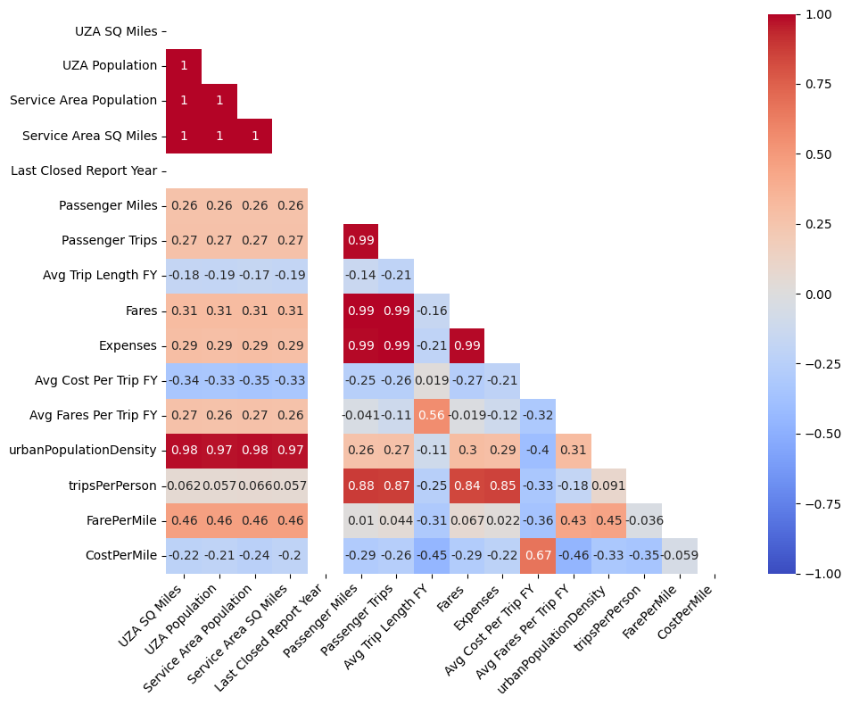

```python
# correlation matrix to see how closely the columns are related and which relationships
# to further investigate

corr_matrix = filtered_data.select_dtypes(include='number').corr()
mask = np.triu(np.ones_like(corr_matrix, dtype=bool))
plot = sns.heatmap(corr_matrix,cmap='coolwarm',mask=mask,vmin=-1,vmax=1,annot=True)
plot.figure.set_size_inches(10,8)
plot.set_xticklabels(plot.get_xticklabels(), rotation=45, ha='right')
plt.tight_layout()
```

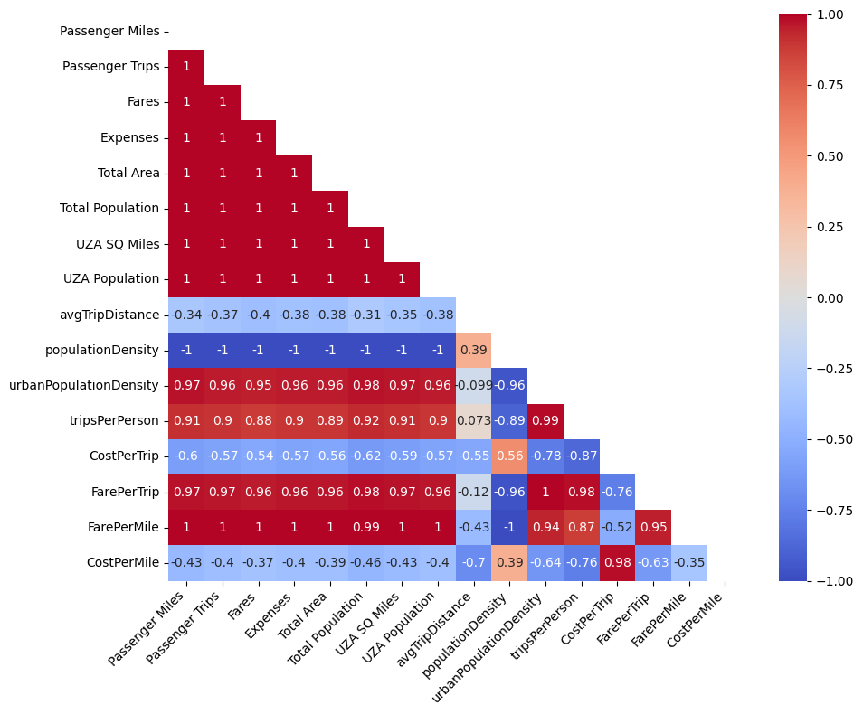

```python
# correlation matrix for the data grouped by agency
# displays extremely high correlations amongst certain variables

corr_matrix = total_byagency.select_dtypes(include='number').corr()
mask = np.triu(np.ones_like(corr_matrix, dtype=bool))
plot = sns.heatmap(corr_matrix,cmap='coolwarm',mask=mask,vmin=-1,vmax=1,annot=True)
plot.figure.set_size_inches(10,8)
plot.set_xticklabels(plot.get_xticklabels(), rotation=45, ha='right')
plt.tight_layout()
```

```python
# analyze the disparity amongst the different routes and their passenger trips
# conclusion: top routes for each neighborhood would greatly skew their
#             aggregated stories

filtered_data.sort_values(by="Passenger Trips",ascending=False)
```

|  | Agency | 3 Mode | Mode/Type of Service Status | UZA SQ Miles | UZA Population | Service Area Population | Service Area SQ Miles | Last Closed Report Year | Passenger Miles | Passenger Trips | Avg Trip Length FY | Fares | Expenses | Avg Cost Per Trip FY | Avg Fares Per Trip FY | urbanPopulationDensity | tripsPerPerson | FarePerMile | CostPerMile |
| --- | --- | --- | --- | --- | --- | --- | --- | --- | --- | --- | --- | --- | --- | --- | --- | --- | --- | --- | --- |
| 3 | King County | Bus | Active | 982.52 | 3544011.0 | 2347800.0 | 2134.0 | 2023.0 | 244710079 | 63485248 | 4.0 | 60386305.0 | 710359423.0 | 11.19 | 0.95 | 3607.062452 | 27.040313 | 0.246767 | 2.902861 |
| 6 | King County | Bus | Active | 982.52 | 3544011.0 | 2347800.0 | 2134.0 | 2023.0 | 20078748 | 10851566 | 2.0 | 10323654.0 | 92304429.0 | 8.51 | 0.95 | 3607.062452 | 4.622015 | 0.514158 | 4.597121 |
| 10 | Spokane Transit Authority | Bus | Active | 171.67 | 447279.0 | 471169.0 | 248.0 | 2023.0 | 40386159 | 8947157 | 5.0 | 5764300.0 | 86749358.0 | 9.70 | 0.64 | 2605.458146 | 18.989273 | 0.142730 | 2.147997 |
| 5 | King County | Rail | Active | 982.52 | 3544011.0 | 2347800.0 | 2134.0 | 2023.0 | 1556379 | 1411817 | 1.0 | 617795.0 | 13964269.0 | 9.89 | 0.44 | 3607.062452 | 0.601336 | 0.396944 | 8.972281 |
| 7 | King County | Bus | Active | 982.52 | 3544011.0 | 2347800.0 | 2134.0 | 2023.0 | 23349034 | 1104484 | 21.0 | 6664059.0 | 10179899.0 | 9.22 | 6.03 | 3607.062452 | 0.470434 | 0.285410 | 0.435988 |
| 0 | King County | Bus | Active | 982.52 | 3544011.0 | 2347800.0 | 2134.0 | 2023.0 | 6470644 | 888663 | 7.0 | 816892.0 | 72095003.0 | 81.13 | 0.92 | 3607.062452 | 0.378509 | 0.126246 | 11.141859 |
| 4 | King County | Bus | Active | 982.52 | 3544011.0 | 2347800.0 | 2134.0 | 2023.0 | 2376398 | 623887 | 4.0 | 341551.0 | 15507155.0 | 24.86 | 0.55 | 3607.062452 | 0.265733 | 0.143726 | 6.525487 |
| 2 | King County | Ferry | Active | 982.52 | 3544011.0 | 2347800.0 | 2134.0 | 2023.0 | 1479694 | 399687 | 4.0 | 1493280.0 | 8625721.0 | 21.58 | 3.74 | 3607.062452 | 0.170239 | 1.009182 | 5.829395 |
| 14 | City of Longview | Bus | Active | 35.19 | 69841.0 | 61598.0 | 31.0 | 2023.0 | 933382 | 242437 | 4.0 | 118577.0 | 4236468.0 | 17.47 | 0.49 | 1984.683149 | 3.935793 | 0.127040 | 4.538836 |
| 8 | Spokane Transit Authority | Bus | Active | 171.67 | 447279.0 | 471169.0 | 248.0 | 2023.0 | 1632916 | 195972 | 8.0 | 426672.0 | 13959791.0 | 71.23 | 2.18 | 2605.458146 | 0.415927 | 0.261295 | 8.548995 |
| 9 | Spokane Transit Authority | Bus | Active | 171.67 | 447279.0 | 471169.0 | 248.0 | 2023.0 | 1365690 | 164955 | 8.0 | 59370.0 | 6995814.0 | 42.41 | 0.36 | 2605.458146 | 0.350097 | 0.043473 | 5.122549 |
| 1 | King County | Bus | Active | 982.52 | 3544011.0 | 2347800.0 | 2134.0 | 2023.0 | 1509526 | 121496 | 12.0 | 105605.0 | 5658724.0 | 46.58 | 0.87 | 3607.062452 | 0.051749 | 0.069959 | 3.748676 |
| 11 | Spokane Transit Authority | Bus | Active | 171.67 | 447279.0 | 471169.0 | 248.0 | 2023.0 | 2933369 | 95655 | 31.0 | 284041.0 | 778566.0 | 8.14 | 2.97 | 2605.458146 | 0.203016 | 0.096831 | 0.265417 |
| 13 | City of Longview | Bus | Active | 35.19 | 69841.0 | 61598.0 | 31.0 | 2023.0 | 103015 | 32057 | 3.0 | 20448.0 | 1594683.0 | 49.75 | 0.64 | 1984.683149 | 0.520423 | 0.198495 | 15.480105 |
| 12 | City of Longview | Bus | Inactive | 35.19 | 69841.0 | 61598.0 | 31.0 | 2023.0 | 3720 | 310 | 12.0 | 0.0 | 45846.0 | 147.89 | 0.00 | 1984.683149 | 0.005033 | 0.000000 | 12.324194 |

## Generate, Save, and Output Visualizations

*Example Visualizations:* The three visualization placeholders below are example visualization placeholders for the data using a provided template. These are simple example frameworks that you may use, but you may, and are encouraged to develop your own visualizations that you will then explain how the selected visualizations support your conclusions in the part two report.

In accordance with the scenario, three neighborhoods for evaluation are: King County, City of Longview, and Spokane Transit Authority which have been listed in the neighborhoods variable above.

This is an example visualization you can generate. You may implement a chart and assessment of your choosing in lieu of this placeholder.

#### At a minimum include the following actions:

- Add title and axis labels
- Save the plot to a png file in the 'output' folder
- Use the display() function to render the generated png image in the html output
- Comments explaining each step of your analysis

## The chart displays that the vast majority of trips for these three neighborhoods have an average length less than about five miles with the largest section being around three to five miles long.

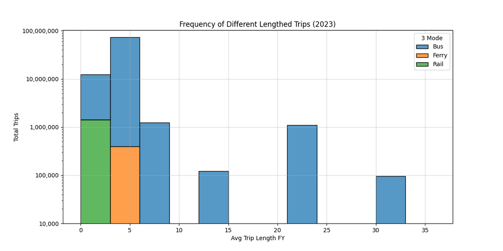

```python
# To Do: Create a visualization that will support your conclusions for part two
test = filtered_data.copy()

ax = sns.histplot(test,
                    weights=(test["Passenger Trips"]),
                    x=(test["Avg Trip Length FY"]),
                    binwidth = 3,
                    hue="3 Mode",
                     multiple='stack',
                     binrange=(0,35))
ax.figure.set_size_inches(12,6)
ax.set_yscale('log')
ax.set_yticks([10000,100000, 1000000,10000000, 100000000])
ax.yaxis.set_major_formatter(ticker.StrMethodFormatter('{x:,.0f}'))
ax.grid(True,alpha=0.5)
ax.set_ylabel('Total Trips')
ax.set_title('Frequency of Different Lengthed Trips (2023)')

# To Do: Save the plot into a png file under the 'output' folder

plt.savefig('output/vis_one.png')
plt.close()

# To Do: Use the display() function to render the generated png image in the html output

display(Image(filename='output/vis_one.png'))
```

This is an example visualization you can generate. You may implement a chart and assessment of your choosing in lieu of this placeholder.

#### At a minimum include the following actions:

- Add title and axis labels
- Save the plot to a png file in the 'output' folder
- Use the display() function to render the generated png image in the html output
- Comments explaining each step of your analysis

## This chart helps to identify the trend between ridership and population size. The expected trend of a higher population means there are more passengers is a fairly obvious statement. But, due to the project at hand, deriving unforeseen insights isn't necessarily the exact goal. Providing relevant, concrete data about what a specific population could expect to demand of a transportation service allows the non-profit to extrapolate this information across other neighborhoods or areas to compare or predict their transportation needs/usage.

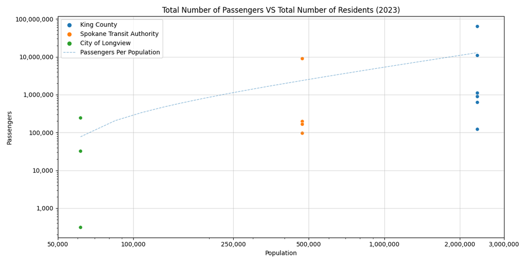

```python
data = filtered_data[filtered_data['3 Mode']=='Bus'].copy()
fig,ax=plt.subplots(figsize=(12,6))

sns.scatterplot(
        data,
        y=(data["Passenger Trips"]),
        x=(data["Service Area Population"]),
        hue="Agency",
        ax=ax)

sns.regplot(
        data,
        y=(data["Passenger Trips"]),
        x=(data["Service Area Population"]),
        scatter=False,
        line_kws={"linestyle": "--",'linewidth':1,'alpha':0.5},
        ci=None,
        label='Passengers Per Population',
        ax=ax)

ax.set_title('Total Number of Passengers VS Total Number of Residents (2023)')
ax.figure.set_size_inches(12,6)
ax.set_yscale('log')
ax.set_xscale('log')
#ax.set_xticks([2347800,471169,61598])
ax.set_xticks([50000,100000,250000,500000,1000000,2000000,3000000])
ax.xaxis.set_major_formatter(ticker.StrMethodFormatter('{x:,.0f}'))
ax.yaxis.set_major_formatter(ticker.StrMethodFormatter('{x:,.0f}'))
ax.legend()
ax.set_xlabel('Population')
ax.grid(True,alpha=0.5)
ax.set_ylabel('Passengers')
plt.tight_layout()

plt.savefig('output/vis_two.png')
plt.close()
display(Image(filename='output/vis_two.png'))
```

This is an example visualization you can generate. You may implement a chart and assessment of your choosing in lieu of this placeholder.

#### At a minimum include the following actions:

- Add title and axis labels
- Save the plot to a png file in the 'output' folder
- Use the display() function to render the generated png image in the html output
- Comments explaining each step of your analysis

## Similar to the previous chart, this chart does not discover any groundbreaking truths about public transportation. The expected trend that more passengers leads to higher expenses is validated in this chart. However, like the previous chart, this chart is able to provide concrete data that allows the non-profit to identify how much exactly a different neighborhood could expect to spend on public transportation based on their expected number of passengers.

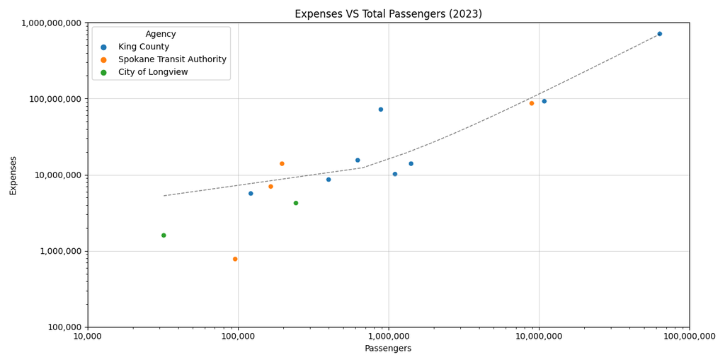

```python
data = filtered_data[['Passenger Trips','Agency','Fares','Expenses','Passenger Miles','Avg Trip Length FY','tripsPerPerson']].copy()
data= data[data['Fares']!=0]
groups = data["Agency"].unique()
palette = dict(zip(groups, sns.color_palette("tab10", len(groups))))
ax = sns.scatterplot(
        data,
        x='Passenger Trips',
        y=data['Expenses'],
        hue='Agency',
        palette=palette
)

sns.regplot(
        data,
        x='Passenger Trips',
        y=data['Expenses'],
        scatter=False,
        line_kws={"linestyle": "--",'linewidth':1,'alpha':0.5},
        ci=None,
        label='Fares vs Expenses',
        ax=ax,
        color='black'
)

ax.figure.set_size_inches(12,6)
ax.set_yscale('log')
ax.set_xscale('log')
ax.set_yticks([100000, 1000000,10000000, 100000000,1000000000])
ax.set_xticks([10000,100000,1000000,10000000, 100000000])
ax.yaxis.set_major_formatter(ticker.StrMethodFormatter('{x:,.0f}'))
ax.xaxis.set_major_formatter(ticker.StrMethodFormatter('{x:,.0f}'))
ax.grid(True,alpha=0.5)
ax.set_title('Expenses VS Total Passengers (2023)')
ax.set_xlabel('Passengers')

# To Do: Save the plot into a png file under the 'output' folder
plt.tight_layout()
plt.savefig('output/vis_three.png')
plt.close()

# To Do: Use the display() function to render the generated png image in the html output

display(Image(filename='output/vis_three.png'))
```